# Shinytone: an introduction

A free, end-to-end tool for citation tone research across tone languages, integrating the full citation-tone analysis workflow into one interactive app.

Designed for phoneticians, typologists, fieldworkers, and students working on lexical tone production.

🌱 Created by [Chenzi Xu](https://chenzixu.rbind.io/) & [Cong Zhang](https://congzhang-linguist.github.io) · github.com/chenchenzi/citationtone_hub

🔓 Open source 💻 Runs in your browser 🆓 Free, no install 🔁 Reproducible

## From recordings to a tone system

Shinytone's end-to-end goal: turn raw audio of words in isolation into a documented citation-tone inventory.

[figure not shown]

One documented, inspectable pipeline: from a folder of recordings to an exportable tone inventory, with the **R code behind every plot and model** available at each step.

[figure not shown]

## Why Shinytone?

A cross-linguistic review of **136 citation-tone studies** across **129 tonal varieties of China** found that methodological choices diverge at almost every step, limiting how well tone inventories can be compared within and across languages.

📈

Inconsistent f0 handling

f0 (the primary acoustic correlate of tone) is measured, normalised, and reported differently across studies.

👥

Small speaker samples

Many descriptions rest on very few speakers, limiting how far their tone inventories generalise.

🔍

Low transparency

Analytical decisions and procedures are often under-documented, so studies are hard to reproduce.

🧩

Limited comparability

These divergences make tone inventories difficult to compare within and across languages.

Issues documented in our cross-linguistic methodological review: [Xu & Zhang (2024), *JASA*](https://doi.org/10.1121/10.0032356). **Shinytone turns its recommendations into one transparent, reproducible pipeline.**

## A garden of forking paths

There is rarely one correct way to analyse a recording, so studies diverge at almost every stage.

[figure not shown]

Seven binary forks alone give **128 distinct pipelines**, about the 136 studies reviewed. Real stages offer far more options, often unreported, so almost no two studies share a path. **Shinytone helps to make a path explicit and reproducible.**

## Tone & terminology

A brief orientation to the linguistic notions Shinytone is built around.

#### 📖 What is tone?

A *tone language* uses pitch contrastively at the lexical level: the same string of consonants and vowels can map to different words depending on the pitch pattern with which it is produced.

“A language is a tone language if the pitch of a word can change the meaning of the word.”

Yip (2002), *Tone*, p. 1.

#### 🎙️ Citation tones

A *citation tone* is the pitch shape a word takes when it is pronounced in isolation, away from the influence of neighbouring words, sentence intonation, or discourse context. This makes it the cleanest starting point for studying a language’s tonal contrasts.

Shinytone is designed for this use case: controlled recordings of single words or short syllables, one tone category per token, multiple speakers and repetitions.

#### 🌊 Pitch vs. f0

Strictly speaking, Shinytone analyses **f0** (fundamental frequency): the *physical* property of a voiced sound, measured in Hertz. **Pitch** is its *perceptual* correlate: how high or low a listener hears the sound.

We say *pitch* informally (*rising pitch*, *falling pitch*), but every measurement, plot, and model output is f0 in Hz, or its by-speaker normalisation in semitones or z-scores.

## What you can do

Two complementary workspaces, from audio recordings to pitch-contour analysis.

### Pitch Measurement F0 Processing tab

Go from raw `.wav` files to clean f0 contours, ready for the analysis pipeline.

🌊

Extract

f0 from audio with `wrassp`, or import Praat `.Pitch` / `.PitchTier` files.

🔧

Correct

Listen, inspect the waveform, and fix extraction errors frame by frame.

### Pitch Contour Analysis F0 Analysis tab

Run the full citation-tone analysis pipeline on f0 measurements (CSV).

🎨

Visualise

Plot f0 contours by tone, with faceting and normalisation.

🔎

Inspect

Flag octave jumps, outliers, and tracking errors.

🌳

Cluster

Group contour shapes into candidate tone categories.

🏷️

Curate

Relabel tone-category variants or exclude tokens.

📊

Model

Polynomials, GCA, and GAMM with tonal defaults.

📋

Summarise

Convert contours into Chao tone numerals (1–5).

## Pitch Measurement F0 Processing tab

Go from raw `.wav` files to clean f0 contours, ready for the analysis pipeline.

🌊Extract

Extract f0 contours from `.wav` using the `wrassp` R package, or import pre-computed Praat `.Pitch` / `.PitchTier` files.

🔧Correct

Review and correct extraction artefacts by listening, inspecting the waveform, and editing individual frames (halve, double, interpolate, smooth, manual entry).

▸ Click a step to preview its screenshot.

[figure not shown]

## Pitch Contour Analysis F0 Analysis tab

Run the full citation-tone analysis pipeline on f0 measurements (CSV).

🎨Visualise

Plot f0 contours by tone, with speaker faceting and normalisation (z-score / semitone).

🔎Inspect

Flag likely f0 artefacts (octave jumps, outliers, tracking errors) via z-scores and jump detection.

🌳Cluster

Discover candidate tone categories from contour shapes: hierarchical clustering with a data-driven or manual cluster count.

🏷️Curate

Re-label tone-category variants for linguistic variation (splits/mergers, colloquial vs. literary readings, sandhi) or exclude mis-elicited tokens.

📊Model

Per-token polynomials, Growth Curve Analysis (GCA), and Generalised Additive Mixed Models.

📋Summarise

Convert tone contours into Chao tone numerals (1–5) for cross-language comparison.

▸ Click a step to preview its screenshot.

[figure not shown]

## Recommended workflows

Five pipelines: the output of each chains into the input of the next; tone discovery is optional.

1

Pitch extraction F0 Processing

🎤 .wav➔ 📊 .Pitch (Praat)or 📊 pre-extracted f0 .csv➔ F0 Extraction (+ metadata)➔ 📊 f0 + metadata .csv

2

Pitch-tracking quality check F0 Analysis

📊 f0 .csv➔ Normalise (optional)➔ Visualise➔ Inspect➔ 📊 f0 + metadata + flags .csv

3

Pitch-tracking correction F0 Processing

🎤 .wav+ 📊 f0 + metadata + flags .csv➔ F0 Correction➔ 📊 cleaned f0 .csv

4

Tone discovery optional path F0 Analysis

📊 clean f0 .csv➔ Normalise➔ Cluster➔ Curate➔ 📊 clean f0 + cluster labels .csv

5

Contour modelling & summary F0 Analysis

📊 clean f0 .csv➔ Normalise➔ Curate (optional)➔ Model➔ Summarise➔ 📋 coefficients / Chao numerals

## Highlights

Beyond bundling existing tools: Shinytone’s methodological contributions.

01

🧩 The whole pipeline, one tool

From raw recordings to publication-ready models and Chao numerals: extraction, screening, correction, normalisation, modelling, and summary in one consistent environment, instead of juggling separate tools, spreadsheets, and ad-hoc scripts.

02

🔎 A new screen for f0 irregularities

Three complementary layers: speaker-level extreme-value (max / min) z-scores, token-level median/MAD z-scores by speaker × tone, and sample-level frame-by-frame jump, octave, and carryover checks with median-aware flag placement, catching halving/doubling, stray frames, and whole-contour shifts.

03

🎧 f0 correction by ear and eye

Every flagged token links back to its audio: listen, read the waveform, and repair individual frames (halve, double, interpolate, smooth, manual entry). Every edit is written to a downloadable log, so quality control is automatically documented and reproducible rather than silent.

04

📐 Comparative Chao tone numerals

Automated conversion of modelled contours into the Chao (1930) 1–5 tone letters, with the reference-line and interval-based methods shown side by side, so the final summary is a transparent, well-justified decision rather than a black-box output, and numerals can always be adjusted to preserve phonetic contrasts.

## Diagnosing f0 irregularities

A three-tier screening system.

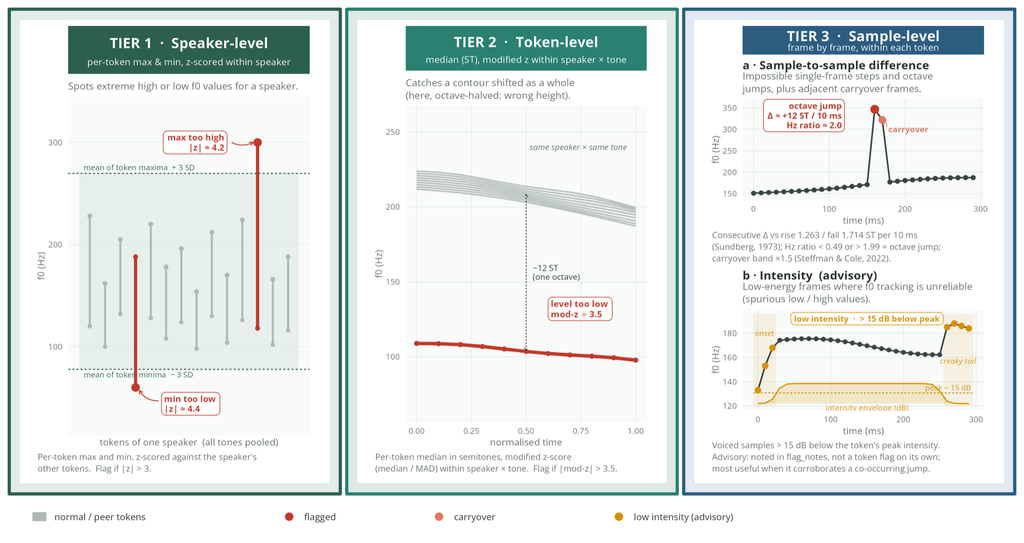

## Shinytone as an R package

Everything the app does is also available as a scriptable, reproducible R package.

[figure not shown]

shinytone · v0.1.1 · GPL (≥ 3)

📘 [Documentation](https://chenchenzi.github.io/citationtone_hub/)  
💻 [Source on GitHub](https://github.com/chenchenzi/citationtone_hub)

```
# install from GitHub
remotes::install_github("chenchenzi/citationtone_hub")

# launch the Shiny app locally
shinytone::run_app()
```

**Same app, no limits.** `run_app()` serves the exact interface, but on your own machine: no upload-size cap, memory ceiling, or session timeout. Ideal for large-scale datasets and recordings that never leave your computer.

normalise_f0()

Per-speaker f0 normalisation in semitones, z-scores, or ERB.

inspect_f0()

Per-token z-scores plus sample-level jump detection.

fit_gca() / fit_gamm()

Growth-curve and GAMM models with citation-tone defaults.

contour_to_chao()

Normalised contour → Chao (1930) 1–5 tone-letter notation.

## Open, free, and reproducible

Lowering the barriers to rigorous, reproducible tonal analysis.

- 🔓**Open source.** Every line is on GitHub under an open licence (GPL ≥ 3), free to inspect, reuse, and extend.
- 💻**No barriers.** Runs in any browser with no install or coding, or install it locally as an R package.
- 🧩**Built on open tools.** R, Shiny, and open phonetics libraries (`wrassp`, `rPraat`, `praatpicture`).
- 🔁**Reproducible.** One documented pipeline; export the underlying R code for every plot and model.
- 🔒**Private by design.** Uploads are processed only in transient session memory, never stored or shared.
- 📚**Grounded & citable.** The analysis methods we preset (f0 normalisation, modelling, and Chao conversion) follow our peer-reviewed methodological review (Xu & Zhang, 2024, JASA).

[GitHub repository](https://github.com/chenchenzi/citationtone_hub) · [📄Methodology paper (JASA 2024)](https://doi.org/10.1121/10.0032356) · 👥[Chenzi Xu](https://chenzixu.rbind.io/) & [Cong Zhang](https://congzhang-linguist.github.io)

Shiny*tone*